# Piecewise Linear Segmentation by Dynamic Programming

Rainer Machne, Peter F. Stadler

10 08 2020

$$\newcommand{\Ell}{\mathcal{L}}
\newcommand{\jump}{\mathcal{J}}
\newcommand{\Var}{\mathrm{Var}}
\newcommand{\Cov}{\mathrm{Cov}}
\newcommand{\lmax}{\ell_\text{max}}
\newcommand{\lmin}{\ell_\text{min}}
\newcommand{\def}{\stackrel{\mathrm{def}}{=}}$$

The R package `dpseg` performs piecewise linear segmentation of 2-dimensional data by a dynamic programming algorithm. It was developed for time series data, dissection of bacterial growth phases, and for genome-wide read-count data from next generation sequencing.

`print`, `plot` and `predict` methods allow quick evaluation of the results. Parameter scanning routines (`estimateP`, `scanP`) help to evaluate the best choice of parameters for a given problem.

The package and its documentation are also intended to serve as a tutorial on the concepts of linear regression, dynamic programming and the segmentation problem. The `movie` function animates the progress of the algorithm through the data. Generic implementations of dynamic programming routines allow to test alternative segmentation criteria.

# 1 Theory

## 1.1 Recursion

The problem is to find break-points in 2-dimensional ordered data $\{(x_i,y_i), i=1,...,n\}$, eg., a time series. This can be formulated as a dynamic programming recursion:

$$\begin{equation}
S_j = \max_{i\le j} (S_{i-\jump} + \text{score}(i,j)) - P\;, \tag{1.1}
\end{equation}$$

where the scoring function $\text{score}(i,j)$ quantifies how well a segment between points $i$ and $j$ is defined.

The break-point penalty term $P$ sets bounds on segment lengths and should be chosen close to the optimal value of the scoring function (section 2.2). Higher $P$ will yield longer segments, and especially for non-monotonic data $P$ lower than the optimal value for the scoring function can work better.

The binary jump parameter $\jump \in \{0,1\}$ determines whether the break-point $i$ is both, the end of the previous and start of the current segment ($\jump=0$), or the previous segments ends at $i-1$ ($\jump=1$). The latter choice allows discontinuous jumps between adjacent segments.

## 1.2 Scoring Functions

Segmentation into linear segments can be achieved by using a goodness-of-fit measure. Linear models are often evaluated by the r-squared value $R^2$, and we can use this directly as a scoring function (`type="r2"` in `dpseg`):

$$\begin{equation}
\text{score}(i,j)= \frac{\sum (\hat y_i - \bar y)^2}{\sum (y_i - \bar y)^2}-1\;,
\tag{1.2}
\end{equation}$$

where $\hat y_i$ is the linear model and $\bar y$ the mean of the original data, see section 6 and equation (6.4) for details.

Subtraction of 1 simply aligns different scoring functions in `dpseg` at $\text{score} \le 0$ and thereby allows the use of a consistent default penalty parameter of $P=0$.

$R^2$ depends on the slope (eq. (6.4)) and will score poorly for segments without slope (Fig. 2.8). The negative variance of the residuals $r_i$ between data and the regression line does not depend on the slope (eq. (6.5)) and is for many cases a better choice

$$\begin{equation}
\text{score}(i,j)= - \frac{1}{n-1} \sum r_i^2\;,
\tag{1.3}
\end{equation}$$

and this is the default `type="var"` in `dpseg`.

Notably, incremental calculation of the variances (section 6) allows for a computationally efficient implementation of the recursion (Fig. 3.1).

## 1.3 Backtracing

During calculation of $S_j$ the position $i_\text{max}<j$ that yielded the maximal score is stored as a vector. The segmentation can be easily retrieved by starting at the last position $j=n$, the end of the last segment, looking up its $i_\text{max}$, the start of the segment, and proceed from $j=i_\text{max} - \jump$ (the end of the next segment). If jumps were allowed ($\jump=1$) the previous segment ended one position ahead of the next segment at $i-1$, and this must be accounted for in backtracing.

```r
simple_backtrace <- function (imax, jumps = 0) {
    end <- length(imax) # end of the first segment = end of the data
    ends <- c(end)      # initiate vector
    while (end > 1) {
        end <- imax[end] - jumps # end of previous segment
        ends <- c(end, ends)     # note the order, new end is prepended
    }
    ends
}
```

## 1.4 Segment Length Restrictions

Depending on the scoring function, short segments may not be meaningful, eg. goodness-of-fit measures for linear regression such as the variance of residuals are 0 for segments of length $\ell=2$ and an "optimal" segmentation would split the data in pairs with perfect "fits". Thus, we can restrict score function maximization for only $i\le(j-\lmin+1)$.

When handling data sets much larger then the expected segment length, one can also define a maximal segment length, and thereby save memory and computation time by only considering $i\ge(j-\lmax +1)$.

$$\begin{equation}
S_j = \max_{\substack{i\le j-\Ell_{\min}\\i\ge j-\Ell_{\max}}} (S_{i-\jump} + \text{score}(i,j)) - P\;.
\tag{1.4}
\end{equation}$$

# 2 Usage

## 2.1 Basic

The main function `dpseg` returns an object of class `dpseg` and results can be inspected by `print`, `plot` and `predict` methods.

The result object is a simple list (`S3` object) with the list item `segments` as the main result: a table (data frame) that lists the start and end x-values of the segments, the start and end indices in the data vectors, the linear regression coefficients and goodness-of-fit measures for the segments (intercept, slope, r-squared, variance of residuals).

```r
library(dpseg)

type <- "var"  # use the (default) scoring, -var(residuals(lm(y~x)))
jumps <- FALSE # allow discrete jumps between segments?
P <- 1e-4      # break-point penalty, use higher P for longer segments

# get example data `oddata` - bacterial growth measured as optical density OD
x <- oddata$Time
y <- log(oddata[,"A2"]) # note: exponential growth -> log(y) is linear

# NOTE: the scoring function results are stored as a matrix for re-use below
segs <- dpseg(x=x, y=y, jumps=jumps, P=P, type=type, store.matrix=TRUE)
```

```
## calculating recursion for 229 datapoints
```

```r
print(segs)
```

```
##
## dynamic programming-based segmentation of 229 xy data points:
##
##          x1        x2 start end  intercept       slope        r2          var
## 1  1.022778  1.362778     1   3  0.7194953 -4.38397708 0.9909440 5.076021e-03
## 2  1.362778  1.703194     3   5 -9.3479269  3.01611065 0.9626144 1.023547e-02
## 3  1.703194  2.213611     5   8 -6.2212774  1.15334663 0.9766701 1.532996e-03
## 4  2.213611  6.982361     8  36 -4.4810363  0.42112342 0.9646807 1.365581e-02
## 5  6.982361  8.688194    36  46 -3.2862340  0.23483030 0.9857475 2.551765e-04
## 6  8.688194 15.689028    46  87 -2.1271834  0.10395130 0.9882125 5.654426e-04
## 7 15.689028 17.911806    87 100 -3.4426960  0.18899698 0.9940106 1.101408e-04
## 8 17.911806 21.329583   100 120 -0.3825874  0.01895679 0.8638382 6.374447e-05
## 9 21.329583 39.940000   120 229  0.4767462 -0.01989881 0.9919736 9.501867e-05
##
## Parameters: type: var; minl: 3; maxl: 229; P: 1e-04; jumps: 0
```

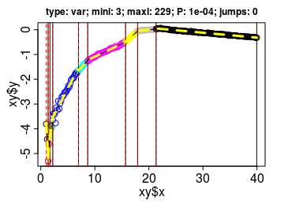

Figure 2.1: Segmentation of a growth curve (*E. coli* in M9 minimal medium) by `dpseg`. Vertical lines indicate segment starts (dashed red) and ends (solid black). The `predict` method returns the piecewise linear model (dashed yellow).

```r
plot(segs)
lines(predict(segs),lty=2, lwd=3, col="yellow")
```

### 2.1.1 Exploratory & Educational Movies

For both, educational purposes or detailed evaluation of novel scoring functions (section 2.5) or parameters, the `movie` function allows to visualize the performance of the dynamic programming as it progresses through the data:

```r
# use options frames, and res to control file size
movie(segs, format="gif", file.name="movie", path="pkg/vignettes/figures",
      frames=seq(1,length(x),3), delay=.3,res=50)
```

This will plot each step of the algorithm and visualize the development of the scoring function. For this function to work, the option `store.matrix=TRUE` must be set in the call to `dpseg`.

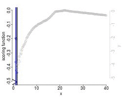

Figure 2.2: Animation of the progress of the algorithm through the data (gray circles and right y-axis). The black vertical line is the current position $j$, and the black circles are the values of the scoring function $\text{score}(i,j)$ for all $i<j$. The blue line was the $i_\text{max}$ where the maximal value of the recursion $S_j$ was found. The thin red line indicates $j-\lmin$. Colors indicate the final segmentation after backtracing.

## 2.2 Selection of the Penalty Parameter $P$

The minimal and maximal segment length parameters `minl` and `maxl` are the easiest way to restrict the algorithm (and memory usage) to certain segment lengths. However, this overrules potentially better segmentations with lower variance.

A more meaningful way to restrict segment lengths for given data is to explicitly allow higher variance of segments. This can be achieved with the break-point penalty parameter $P$. This parameter can be directly used to tune segmentation. It can be chosen in the order of magnitude of the tolerated variances. A higher $P$ will allow higher variance of the individual segments and yield longer segments.

To choose an optimal $P$ for a given application, the package offers two functions: `estimateP` and `scanP`. `estimateP` makes use of the excellent performance of base R's `smooth.spline` implementation and reports the variance of the residuals; option `plot=TRUE` allows to evaluate results:

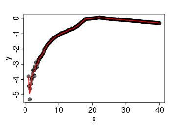

```r
p <- estimateP(x=x, y=y, plot=TRUE)
```

```
## calculating recursion for 229 datapoints
```

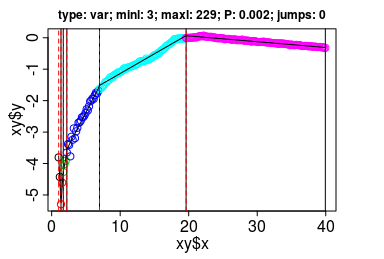

```r
plot(dpseg(x=x, y=y, jumps=jumps, P=round(p,3)))
```

The reported value is a good starting point. For our example data, values an order of magnitude lower than this estimate, $P$`=estimateP(x=x,y=y)/10` achieved a satisfying segmentation, but this will strongly depend on the type of data and noise around expected segments.

Alternative estimators can be easily defined, eg. `estimateP` simply calls `smooth.spline`:

```r
simple_estimateP <- function (x, y, ...) {
    var(smooth.spline(x, y, ...)$y - y)
}
```

The convenience function `scanP` calculates segmentations for a vector of $P$ values and returns (plots) the resulting numbers of segments and the median of segment variances of residuals. Based on these values one can select a value of $P$ that splits the data into a reasonable number of segments with acceptable variance of residuals:

```
## running dpseg 50 times: ..................................................
```

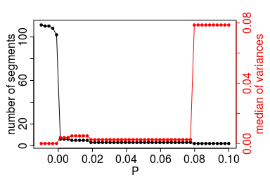

Figure 2.3: A higher $P$ will yield fewer and longer segments. $P$ should be chosen close to the optimal value of the scoring function.

```r
## NOTE: dpseg is slower for many segments!
sp <- scanP(x=x, y=y, P=seq(-.01,.1,length.out=50), plot=TRUE)
```

## 2.3 Pre-Calculated Scoring Matrix

When the scoring function can be pre-calculated, a simple look-up in the triangular matrix (banded by $\lmin$ and $\lmax$) suffices for the recursion. This option is available in `dpseg` by passing a scoring matrix $\mathbf{S}_{ij}$ as argument `y` (instead of a numeric vector).

For example, we can use the scoring matrix generated above (stored due to option `store.matrix=TRUE`) and test different parameters $P$, $\jump$, $\lmin'>\lmin$ and $\lmax'<\lmax$ more efficiently (section 3). This approach is also used in the `scanP` function (section 2.2).

```r
## use the scoring matrix from previous run for generic recursion,
## with store.matrix=TRUE, and test different parameters.
segm <- dpseg(y=segs$SCR, jumps=jumps, P=2*P, minl=5, maxl=50)
```

```
## setup use with pre-calculated scoring matrix
## calculating recursion for 229 datapoints
```

```r
print(segm)
```

```
##
## dynamic programming-based segmentation of 229 xy data points:
##
##    x1  x2 start end
## 1   1  37     1  37
## 2  37  46    37  46
## 3  46  87    46  87
## 4  87 100    87 100
## 5 100 131   100 131
## 6 131 180   131 180
## 7 180 229   180 229
##
## Parameters: type: matrix; minl: 5; maxl: 50; P: 2e-04; jumps: 0
```

Note, that in this case the algorithm does not use or know of the original $x,y$ data and the result therefore contains only the segment break-point indices in the original data vectors. The `predict` and `plot` functions will not work. We can use the convenience function `addLm` to add the original $x,y$ data and linear regression coefficients (via `lm`) for the calculated segments:

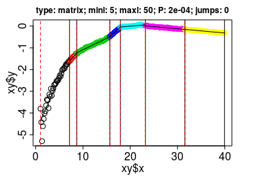

Figure 2.4: Compared to the first run above both, the larger $\lmin=5$ and $P=0.0002$, contributed to get fewer segments, while the lower $\lmax=50$ split the last segment in two.

```r
## add lm-based regression coefficients
segm <- addLm(segm, x=x, y=y)
plot(segm)
```

## 2.4 Alternative Scoring Functions

The performance of different scoring functions and penalty parameters depends on the type of data. Using the non-monotonic, sine-based [example data from the `RcppDynProg` R package](https://win-vector.com/2018/12/31/introducing-rcppdynprog/) (Mount and Zumel 2019), we can first use `scanP` to test different penalties for different scoring functions. Here, `dpseg` yields the intended segmentation with the default scoring function (`type="var"`) and a negative penalty, while the Pearson correlation (`type="cor"`) worked well with default penalty $P=0$:

```r
## example from https://winvector.github.io/RcppDynProg/articles/SegmentationL.html
set.seed(2018)
d <- data.frame(x = 0.05*(1:(300))) # ordered in x
d$y_real <- sin((0.3*d$x)^2)
d$y <- d$y_real + 0.25*rnorm(length(d$y_real))

par(mfrow=c(2,2))
scanP(x=d$x, y=d$y, P=seq(-0.005,0,length.out=50), verb=0) # note: no messages by verb=0
```

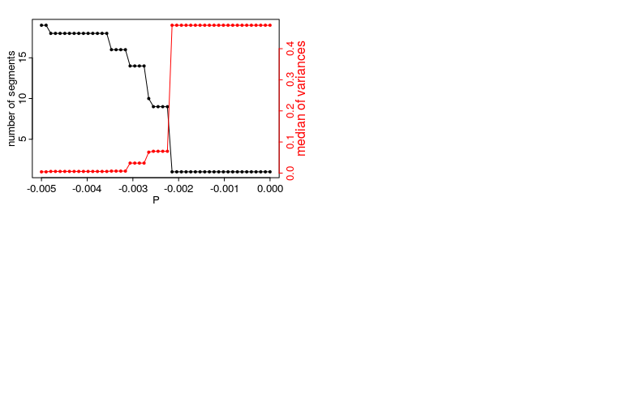

Figure 2.5: Segmentation of the test data from the RcppDynProg package with the default scoring function, negative variance of residuals (left), and with Pearson correlation (right).

```r
scanP(x=d$x, y=d$y, P=seq(-0.05,0,length.out=50), type="cor", verb=0)
```

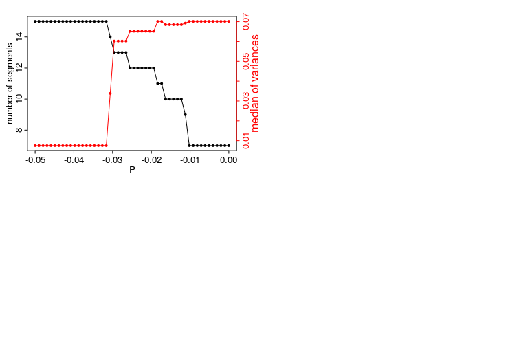

Figure 2.6: Segmentation of the test data from the RcppDynProg package with the default scoring function, negative variance of residuals (left), and with Pearson correlation (right).

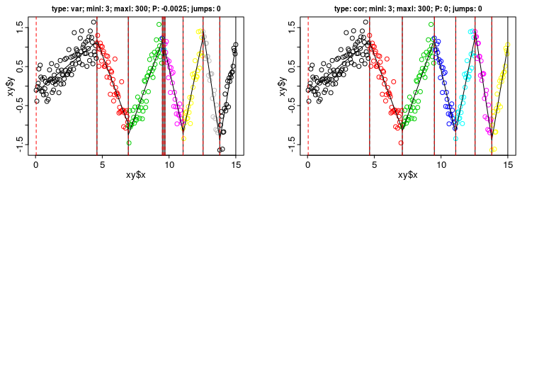

Figure 2.7: Segmentation of the test data from the RcppDynProg package with the default scoring function, negative variance of residuals (left), and with Pearson correlation (right).

```r
plot(dpseg(x=d$x, y=d$y, P=-.0025, verb=0))
plot(dpseg(x=d$x, y=d$y, type="cor", verb=0))
```

## 2.5 Custom Scoring Functions

Alternative scoring functions can be tested easily by either providing a scoring matrix $\mathbf{S}_{ij}$ as described above, or by providing the `score(i,j)` function directly. The latter can be achieved by defining a score function with the signature as in the following example, testing to use the coefficient of determination $R^2$ (r-squared) for segmentation:

Since our scoring function doesn't provide linear regression parameters, we can use the option `add.lm=TRUE` to add intercept and slope data via base R's `lm`, required for the `predict` and `plot` methods.

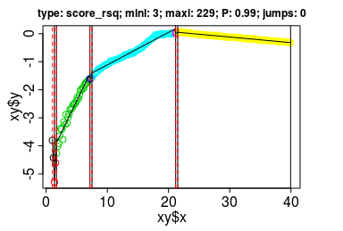

Figure 2.8: Note, that as above a meaningful penalty term $P$ should be close to the optimal value of the scoring function, here $R^2=1$.

```r
score_rsq <- function(i, j, x, y,...) summary(lm(y[i:j]~x[i:j]))$r.squared
segn <- dpseg(x=x, y=y, jumps=jumps, P=.99, scoref=score_rsq, add.lm=TRUE)
plot(segn)
```

# 3 Benchmarking

The implementation of equation (1.4) is straightforward. Section 5 shows a fully functional implementation in about 30 lines of code in R. However, this is highly inefficient. The theoretical complexity is quadratic, ie. $\mathcal{O}(n^2)$, and even with segment length restrictions a linear regression with base R's `lm` function is performed $(n-1)*(\lmax-\lmin+1)$ times.

A more efficient implementation calculates the linear regression parameters incrementally (eq. (1.3) and section 6) while looping through the data. Benchmarking of different implementations, using a growth curve of a culture of *Escherichia coli* cells, showed that this incremental implementation was about 2 orders of magnitude faster then the generic implementation, and another 2 orders of magnitude faster when implemented in `C++` via the `Rcpp` package (Fig. 3.1). The latter approach is thus the default recursion used in `dpseg`.

The function `piecewise_linear` of the related package `RcppDynProg` (Mount and Zumel 2019) (version 0.1.3, without weights) was only slightly faster than incremental calculation in base R and ca. 100x slower than the default implementation of `dpseg`.

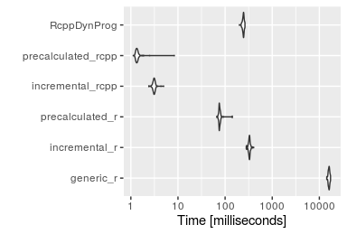

Figure 3.1: Benchmarking of R & Rcpp implementations.

# 4 Related Packages and Algorithms

Segmentation by dynamic programming:

- Segmentation by dynamic programming (Lemire 2007) and more detailed arXive version in (Lemire 2006),
- The `RcppDynProg` R package (Mount and Zumel 2019) follows a very similar approach to `dpseg`, see https://cran.r-project.org/package=RcppDynProg and https://win-vector.com/2018/12/31/introducing-rcppdynprog/ ,
- Similarity-based segmentation of multi-dimensional signal by dynamic programming (Machne, Murray, and Stadler 2017) is implemented with time-series clustering-based similarities in the R package https://cran.r-project.org/package=segmenTier.

Piecewise linear segmentation by alternative approaches:

- Piecewise linear segmentation , where initial values for a fixed number of break-points must be specified (V. Muggeo 2003); implemented in R package `segmented` uses a Boolean restarting method (V. M. R. Muggeo 2008),
- Bayesian piecewise growth mixture models with pre-defined number of segments in R package `BayesPGGM` (Lock, Kohli, and Bose 2018).

# 5 Dynamic Programming in base R

The implementation of the recursion (1.4), the scoring function (1.3) and the `backtrace` is straightforward:

```r
## RECURSION
recursion <- function(x, y,  maxl, jumps=0, P=0, minl=3, S0=1) {
  N = length(x)
  S = numeric(N) # init to 0
  imax = numeric(N)
  S[1] = -P
  for ( j in 2:N) {
    si = rep(-Inf, maxl-minl+1)
    irng = (j-maxl):(j-minl) +1
    irng = irng[irng>0]
    for ( i in irng ) {
      idx = i-(j-maxl)
      sij = ifelse(i==1&jumps==1, S0, S[i-jumps])
      si[idx] = sij + score(x, y, i, j) - P
    }
    S[j] = max(si)
    idx = which.max(si)
    imax[j] = idx + (j-maxl)
  }
  imax
}

## SCORING FUNCTION
score <- function(x, y, k, l) -var(residuals(lm(y[k:l]~x[k:l])))

## backtracing
backtrace <- function(imax, jumps=0) {
  end = length(imax) # end of last segment
  ends = end
  while( end>1 ) {
    end = imax[end] - jumps
    ends = c(end, ends)
  }
  ends[1] <- ends[1] + jumps # note: start of first segment
  ends
}
```

We construct a simple test case, with three linear segments without jumps, and added noise:

```r
# simple test case
k1=1
k2=.05
k3=-.5
y1 <- k1*1:5
y2 <- k2*1:5 + k1*5
y3 <- k3*1:5 + k2*5 + k1*5
set.seed(1)
ym <- c(y1, y2, y3)
nsd <- .25 # noise, standard deviation
y <- ym + rnorm(length(ym), 0, nsd) # add noise
x <- 1:length(y)

## run recursion
JUMPS = 0
imax = recursion(x, y, maxl=length(x), jumps=JUMPS, P=0, minl=3, S0=1)

## backtrace
ends = backtrace(imax, jumps=JUMPS)
print(ends)
```

```
## [1]  1  5 10 15
```

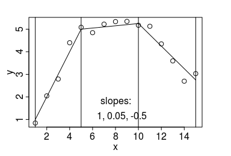

```r
## plot
plot(x,y)
lines(x,ym)
legend("bottom", title="slopes:", legend=paste(k1,k2,k3,sep=", "), bty="n")
abline(v=ends)
```

# 6 Incremental Linear Regression

Summarized values such as the `mean` can not be calculated incrementally, ie. while looping through the data $i=1,...,n$. We are looking for a method to calculate linear regression parameters incrementally for an efficient implementation of the dynamic programming recursions (eq. (1.1) and (1.4)).

## 6.1 Least-Squares Method

Consider $n$ measured data pairs $\{(x_i,y_i), i=1,...,n\}$, with the dependent variable $y_i$ (eg. a measured value) and independent variable $x_i$ (eg. the time of measurement), for which we suspect a linear relation with intercept $\beta_0$ and slope $\beta_1$, and with added random measurement errors, in regression analysis denoted the residuals $r_i$:

\begin{align} y_i &= \beta_0 + \beta_1 x_i + r_i \end{align}

The goal is to find a straight line, denoted the regression line, that best describes this linear relation:

\begin{align} \hat{y}_i &= b_0 + b_1 x_i\;. \end{align}

The gold standard approach to find the regression line is to minimize the sum of squares of the residuals: $\min\limits_{\beta_0,\beta_1} \sum r_i^2$. We treat the data as constants and look for parameters $b_0$ and $b_1$, estimators of the real parameters $\beta_0$ and $\beta_1$, that minimize the deviation of the data from this line.

$$\begin{equation}
f(\beta_0, \beta_1) = \sum_{i=1}^n r_i^2 = \sum_{i=1}^n (y_i-\beta_0-\beta_1 x_i)^2 \tag{6.1}
\end{equation}$$

Note that for clarity we shorten the sum symbol from now on as: $\sum = \sum_{i=1}^n$. It is important not to mix such estimators with the real parameters, since we do not know how accurate our estimation will be. The real parameters $\beta_0$ and $\beta_1$ reflect the actual physical process that underlies the data we measured.

To minimize the residuals, we get the partial derivatives and set them to 0.

$$\begin{align}
\frac{\partial f}{\partial \beta_0} \vert_{b_0} &= \sum 2\cdot (y_i-b_0-\beta_1 x_i)\cdot 1 &=0\\
&= 2 \sum y_i - 2 n b_0 - 2 \beta_1 \sum x_i &=0\\
b_0 &= \frac{1}{n}\sum y_i - \beta_1 \frac{1}{n} \sum x_i\\\hline
\frac{\partial f}{\partial \beta_1} \vert_{b_1} &= \sum 2\cdot (y_i-\beta_0-b_1 x_i)\cdot x_i &=0\\
&= \sum x_i y_i - \beta_0 \sum x_i - b_1 \sum x_i^2 &=0
\end{align}$$

Combining both minimization criteria, with $b_0=\beta_0$ and $b_1=\beta_1$:

$$\begin{align}
\sum x_i y_i - \left(\frac{1}{n}\sum y_i - b_1 \frac{1}{n} \sum x_i\right) \sum x_i - b_1 \sum x_i^2 =0\\
\sum x_i y_i - \frac{1}{n}\sum y_i \sum x_i + b_1 \frac{1}{n} \left(\sum x_i\right)^2 - b_1 \sum x_i^2 =0\\
\sum x_i y_i - \frac{1}{n}\sum y_i \sum x_i = b_1 \left(\sum x_i^2 - \frac{1}{n} \left(\sum x_i\right)^2\right)\\
b_1 = \frac{\sum x_i y_i - \frac{1}{n}\sum y_i \sum x_i}{\sum x_i^2 - \frac{1}{n} \left(\sum x_i\right)^2}
\end{align}$$

Introducing the arithmetic mean, $\bar{x} = \frac{1}{n} \sum_{i=1}^n x_i$, and using the centered form of the variance, we obtain the well known equation for linear regression:

$$\begin{align}
b_0 &= \bar y - b_1 \bar x\\
b_1 &= \frac{\sum(x_i-\bar x )(y_i-\bar y)}{\sum(x_i-\bar x)^2}\;. \tag{6.2}
\end{align}$$

This can be understood intuitively, especially the centered form. It contains the sum of the squared differences of the $x_i$ data points from their arithmetic mean $\bar x$, as well as a similar expression with the products of $x$ and $y$ data. These "sums of squares (products)" ($SQ$) are a measure of the spread of the data around their mean, known as variance (covariance).

Required Differentiation Rules:

- $(f(x)+g(x))' = f'(x) + g'(x)$,
- $(f(x)^2)' = 2 \cdot f(x) \cdot f'(x)$.

Required Summation Rules:

- $\sum_{i=1}^n (a_i+b_i) = \sum_{i=1}^n a_i + \sum_{i=1}^n b_i$,
- $\sum_{i=1}^n(c a_i) = c \sum_{i=1}^n a_i$,
- $\sum_{i=1}^n c = n c$,
- also good to know, no rule for $\sum_{i=1}^n (a_i b_i)$.

## 6.2 Incremental Calculation

The last step to obtain equation (6.2) is known in German as *Verschiebungssatz von Steiner* (Steiner translation theorem), in French as *théorème de König-Huygens*. In English this transformation has no special name and the two forms are just known as the centered (left) and expanded (right) forms of the variance:

\begin{equation} \sum(x_i-\bar x)^2= \sum x_i^2 - n \bar x^2 = \sum x_i^2 - \frac{1}{n}(\sum x_i)^2\;. \end{equation}

We can apply this to all sum of squares required to calculate various statistical measures of the data:

$$\begin{align}
S_{xx} \def & \sum(x_i - \bar x)^2 &=& \sum x_i^2 - \frac{1}{n} (\sum x_i)^2\\
S_{yy} \def & \sum(y_i - \bar y)^2 &=& \sum y_i^2 - \frac{1}{n} (\sum y_i)^2\\
S_{xy} \def & \sum(y_i - \bar y)(x_i - \bar x) &=& \sum y_i x_i - \frac{1}{n} \sum y_i\sum x_i
\tag{6.3}
\end{align}$$

Their expanded forms consist of additions of simple sums of the data, and will thus allow to calculate the sum of squares incrementally by adding up the sum expressions $\sum x_i^2$, $\sum x_i$, $\sum y_i^2$, $\sum y_i$, and $\sum x_i y_i$.

An important caveat is that the expanded forms can become 0 for large $\bar x^2$, known as "catastrophic cancellation".

## 6.3 Useful Definitions

For completeness and context, we provide some standard definitions in statistics literature.

### 6.3.1 Variance & Covariance

Normalizing the sum of squares by the number of data points provides the **variance**, $\Var(x)$:

$$\begin{align}
&\; \tilde s_x^2 =& \frac{1}{n} S_{xx}\\
\Var(x) \def &\; s_x^2 =& \frac{1}{n-1}S_{xx}
\end{align}$$

The intuitive normalization by all data points $n$ is often denoted the "empirical variance", in German "mittleres Abweichungsquadrat". Statistics packages usually use the second version, normalized by $n-1$, the "degrees of freedom", and denoted the "theoretical variance" or "inductive variance", in German *Stichprobenvarianz*. This corrected version accounts for the fact that the deviation of the last value $x_n$ from the mean is already defined by the first 1 to $n-1$ values. It does not further contribute to the spread of the data. Correcting $\tilde s^2$ by multiplication with $\frac{n}{n-1}$ is in German textbooks sometimes called *Bessel-Korrektur*.

Again a similar concept exists combining $x$ and $y$ data, and this is called **co-variance**, $\Cov(x,y)$:

$$\Cov(x,y) \def s_{xy}^2 = \frac{1}{n-1} S_{xy}\;.$$

Going back to our residual error minimization in equation (6.2), we see that the slope of our regression line is given by the ratio of the data co-variance over the variance of the $x$ data, and the normalization terms are canceled out:

$$b_1 = \frac{\Cov(x,y)}{\Var(x)}\;.$$

### 6.3.2 Standard Deviation & Standard Error

Above symbols $s^2$ refer to the sum of squares or products and accordingly have squared or two different units. To directly compare the spread of the data with the data itself, eg. the mean of the data, we simple take the (positive) square root of the variances to obtain the well known **standard deviation**:

$$s = \sqrt{s^2} \;.$$

The standard deviation is a very useful measure in conjunction with the mean, if we a are interested how wide the population data are spread around a mean, consider eg. body height distributions. Ie. if the thing we measure actually varies.

If we are more interested in the "precision of the mean" value of our measurements, ie. if we are sure that the thing we measure does not vary, eg. the mass of an atom, and most variation of measurement values just comes from errors of our measurement device, we further normalize the standard deviation to obtain the **standard error**:

$$e = \frac{s}{\sqrt n}\;.$$

In short, if we expect actual variation of the measured phenomenon, the standard deviation is the measure of choice, while standard error is an estimate of the precision of a measurement device, eg. chemical or optical probes.

## 6.4 Incremental Calculation of Scoring Functions

Let's keep these definitions in mind but return to linear regression. The aim was to obtain expressions that we can calculate incrementally. We have found a regression line that minimizes the sum of squares of the residuals, the distance of actual measured values $y$ from the regression line $\hat y_i$.

### 6.4.1 Coefficient of Determination: $R^2$

To judge how well the regression line describes our data we can define a new term that quantifies the fraction of the spread of the data that can be explained by the regression line. Again "sum of squares" measures are used. The "Sum of sQuares Explained" ($SQE$) describes the spread of our prognosed data $\hat y_i$ around the mean of the original data $\bar y$:

\begin{equation} SQE \def \sum (\hat y_i - \bar y)^2\;, \end{equation}

and the "Sum of sQuares Total" ($SQT$) describes the total spread of the data around its mean:

\begin{equation} SQT \def \sum (y_i - \bar y)^2 = S_{yy}\;. \end{equation}

Their ratio is the fraction of the total data spread that we can explain by our regression line, often denoted **r-squared**:

$$R^2 \def \frac{SQE}{SQT}\;,$$

which reaches $R^2\rightarrow 1$ for a perfect fit. We have already introduced $SQT$ as $S_{yy}$ in equation (6.3). To calculate $SQE$ we replace the defining terms by our regression results:

$$\begin{align}
SQE = \sum (\hat y_i - \bar y)^2 &= \sum(b_0 + b_1 x_i - (b_0 + b_1 \bar x))^2\\
&= \sum(b_1(x_i - \bar x))^2\\
&= b_1^2 \sum (x_i - \bar x)^2\\
&= \left(\frac{S_{xy}}{S_{xx}}\right)^2S_{xx} = \frac{S_{xy}^2}{S_{xx}}
\end{align}$$

and get:

$$\begin{equation}
R^2 = \frac{SQE}{SQT} = \frac{S_{xy}^2}{S_{xx}S_{yy}} = b_1 \frac{S_{xy}}{S_{yy}} = \frac{\Cov(x,y)}{\Var(x)}\cdot\frac{\Cov(x,y)}{\Var(y)}\;,
\tag{6.4}
\end{equation}$$

for which we can obtain all values incrementally *via* the expanded forms of the sum of squares $S_{xy}$, $S_{xx}$ and $S_{xy}$ in equation (6.3).

Notably, r-squared is also the squared version of the **Pearson correlation** $r$:

$$| r | = \sqrt{R^2} = \frac{| S_{xy} |}{\sqrt{S_{xx}S_{yy}}} \;,$$

and both, r-squared (`type="r2"`) and Pearson correlation (`type="cor"`) can be used as optional scoring functions of `dpseg`, where -1 is subtracted (eq. (1.2)) to allow a consistent default penalty parameter $P=0$.

### 6.4.2 Variance of Residuals: $s_r^2$

The r-squared value reflects a direct linear dependence of $y$ on $x$ values, and depends on the slope $b_1\ne0$. When segmenting a curve into linear parts, the $R^2$-based goodness-of-fit measure ignores regions without change in $y$ at $b_1\approx 0$, where data spreads around a mean value $\bar y= b_0$. This can be seen in Figure 2.8 where a short "horizontal" segment of the data is ignored when using $R^2$ as scoring functions.

Minimization of the variance of the residuals is independent of the slope and is thus a better optimization criterium for such cases:

$$s_r^2 = \frac{1}{n-1} \sum (r_i-\bar r)^2= \frac{1}{n-1} \sum r_i^2\;,$$

where $\sum r_i = \bar r=0$ follows from the condition of the minimization $\frac{\partial f}{\partial \beta_0} \vert_{b_0}=0$ of equation (6.1).

Minimization of the "Sum of sQuares of the Residuals" ($SQR$) was the initial optimization criterium (eq. (6.1)):

$$SQR \def \sum r_i^2 = \sum(y_i- \hat y_i)^2\;,$$

and an expression for incremental calculation is obtained by partitioning the residual sum of squares (*Quadratsummenzerlegung*):

$$\begin{align}
\sum(y_i- \bar y_i)^2 &= \sum(y_i- \bar y_i + \hat y_i - \hat y_i)^2\\
&= \sum((\hat y_i -\bar y)+(y_i- \hat y_i))^2\\
&= \sum((\hat y_i -\bar y)+ r_i)^2\\
&= \sum((\hat y_i - \bar y)^2 + r_i^2 + 2 r_i \hat y_i - 2 r_i \bar y)\\
&= \sum(\hat y_i - \bar y)^2 + \sum r_i^2 + 2 \sum r_i \hat y_i - 2 \bar y \sum r_i\\
\sum(y_i- \bar y_i)^2 &= \sum(\hat y_i - \bar y)^2 + \sum r_i^2 \\
SQT &= SQE + SQR\;,
\end{align}$$

again with $\sum r_i = 0$.

In other words the total spread of the data is the sum of the spread explained by our regression line $\hat y$ and the spread that remains in the un-explained residuals. We can obtain the latter as:

$$\begin{align}
\sum r_i^2 &= \sum(y_i- \bar y_i)^2 - \sum(\hat y_i - \bar y)^2 = SQT - SQE\;,
\end{align}$$

and the variance of the residuals as:

$$\begin{equation}
s_r^2 = \frac{1}{n-1} \sum r_i^2
= \frac{1}{n-1}\left(S_{yy} - \frac{S_{xy}^2}{S_{xx}}\right)
= \Var(y) - \frac{\Cov(x,y)^2}{\Var(x)}\,,
\tag{6.5}
\end{equation}$$

which allows incremental calculation from the expanded forms of the sum of squares $S_{xy}$, $S_{xx}$ and $S_{xy}$ in equation (6.3).

The negative $-s_r^2$ is used as the default scoring function (`type="var"`, eq. (1.3)) of `dpseg`.

# References

Lemire, Daniel. 2006. “A Better Alternative to Piecewise Linear Time Series Segmentation.” *CoRR* abs/cs/0605103. https://arxiv.org/abs/cs/0605103.

———. 2007. “A Better Alternative to Piecewise Linear Time Series Segmentation.” In *Proceedings of the 2007 SIAM International Conference on Data Mining*, 545–50. SIAM. doi:10.1137/1.9781611972771.59.

Lock, E.F., N. Kohli, and M. Bose. 2018. “Detecting Multiple Random Changepoints in Bayesian Piecewise Growth Mixture Models.” *Psychometrika* 83 (3): 733–50. doi:10.1007/s11336-017-9594-5.

Machne, R., D.B. Murray, and P.F. Stadler. 2017. “Similarity-Based Segmentation of Multi-Dimensional Signals.” *Sci Rep* 7 (1): 12355. doi:10.1038/s41598-017-12401-8.

Mount, John, and Nina Zumel. 2019. *RcppDynProg: ’Rcpp’ Dynamic Programming*. https://CRAN.R-project.org/package=RcppDynProg.

Muggeo, V. M. R. 2008. “Segmented: An R Package to Fit Regression Models with Broken-Line Relationships.” *R News* 8 (1): 20–25. https://CRAN.R-project.org/doc/Rnews/.

Muggeo, V.M. 2003. “Estimating Regression Models with Unknown Break-Points.” *Stat Med* 22 (19): 3055–71. doi:10.1002/sim.1545.